# data wrangling

LUIZA DIVINO

2024-11-19

# Clean and tag corpus

1. First of all, it is necessary to upload the corpus into Rstudio. The corpus is in PDF format.

```r
dom_casmurro_pdf <- pdf_text("data/domCasmurro.pdf")
```

2. Transform the pdf to tibble separates the whole book in different pages. It is also necessary to tokenize the corpus word by word. For different types of analysis, it is interesting to have the data divided by `page` and also by `word`. It is also necessary to flatten the corpus to tag it. This will leave us with two datasets and one “value string”: `dom_casmurro_page`, `dom_casmurro_word` and `dom_casmurro_text`.

```r
# Data transformation to page
dom_casmurro_pages <- tibble(page = 1:length(dom_casmurro_pdf), text = dom_casmurro_pdf)

# Flatten the data to tag it
dom_casmurro_text <- str_flatten(dom_casmurro_pages$text)

# Text tokenization by word + lowercase
dom_casmurro_words <- dom_casmurro_pages %>%
  unnest_tokens(word, text) %>%
  mutate(word = str_to_lower(str_trim(word)))
```

3. In order to have easier access to content word frequency, it is important to clean the corpus by adding a stop word list with function words. I decided to use the package `stopwords`, where I had three source options. After testing all three, `nlkt` was the one which showed the best result, so I decided to use it. After checking the word frequency list, I added some more words to the list because I noticed some verbs were still there. I checked the list up to 50 occurrences because it would affect the word cloud. I decided no to take “capítulo” (chapter) out because the narrator uses it also inside the text, not only to name each chapter.

```r
# Creating stop word list
stopwords_pt <- c(stopwords(
  "pt", source = "nltk"),
  "disse",
  "ser",
  "lo",
  "ia",
  "dizer",
  "fez",
  "pode",
  "la",
  "ir",
  "ver",
  "podia",
  "vi",
  "falar",
  "quis",
  "sei",
  "ter"
  )

# Adding stop word list
dom_casmurro_words_filtered <- dom_casmurro_words %>%
  filter(!word %in% stopwords_pt)
```

4. For the corpus to be tagged, I chose the `portuguese-bosque` language model because it is a Portuguese treebank that includes both Brazilian and European Portuguese.

```r
# Activating klippy for copy-to-clipboard button
klippy::klippy()
```

```r
# Downloading model
port_model <- udpipe_download_model(language = "portuguese-bosque")
```

[output not shown]

[output not shown]

[output not shown]

[output not shown]

```r
# Load model
port <- udpipe_load_model(file = port_model$file_model)

# Tag corpus
dom_casmurro_pos <- udpipe::udpipe_annotate(port, x = dom_casmurro_text) %>%
  as.data.frame()
```

# Data analysis

### Wordcount

After cleaning the corpus, the next step was to check word frequency. As it is possible to see, `Capitu` is the word the comes up the most.

```r
dom_casmurro_words_filtered %>%
  count(word, sort = TRUE) %>%
  head(n = 10)
```

```
## # A tibble: 10 × 2
##    word         n
##    <chr>    <int>
##  1 capitu     341
##  2 mãe        229
##  3 dias       192
##  4 tudo       189
##  5 capítulo   188
##  6 casa       170
##  7 olhos      164
##  8 mim        162
##  9 josé       160
## 10 assim      158
```

This is also visible in this wordcloud, which shows all the words that occur more than 50 times

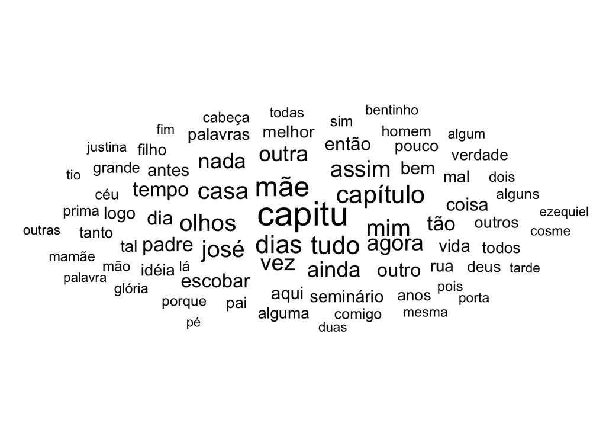

```r
dom_casmurro_words_filtered %>%
  count(word, sort = TRUE) %>%
  filter (n > 50) %>%
  ggplot(aes(label = word, size = n)) +
  geom_text_wordcloud() +
  scale_size_area(max_size = 10) +
  theme_minimal()
```

## Capitu

After seeing the wordcloud, I decided to look for specific terms with “Capitu”

```r
capitu_data <- dom_casmurro_pos %>%
  filter(token == "Capitu")

dom_casmurro_pos %>%
  mutate(word_before_capitu = str_extract_all(sentence, "(\\b\\w+\\s+){5}Capitu")) %>%
  unnest(word_before_capitu) %>%
  filter(!is.na(word_before_capitu)) %>%
  head()
```

```
## # A tibble: 6 × 15
##   doc_id paragraph_id sentence_id sentence      token_id token lemma upos  xpos
##   <chr>         <int>       <int> <chr>         <chr>    <chr> <chr> <chr> <chr>
## 1 doc1            107         386 Com que entã… 1        Com   com   ADP   <NA>
## 2 doc1            107         386 Com que entã… 2        que   que   PRON  <NA>
## 3 doc1            107         386 Com que entã… 3        então então ADV   <NA>
## 4 doc1            107         386 Com que entã… 4        eu    eu    PRON  <NA>
## 5 doc1            107         386 Com que entã… 5        amava amar  VERB  <NA>
## 6 doc1            107         386 Com que entã… 6        Capi… Capi… PROPN <NA>
## # ℹ 6 more variables: feats <chr>, head_token_id <chr>, dep_rel <chr>,
## #   deps <chr>, misc <chr>, word_before_capitu <chr>
```

#### Verbs after Capitu

```r
verbs_after_capitu <- dom_casmurro_pos %>%
  mutate(next_word = lead(sentence), next_pos = lead(upos)) %>%
  filter(token == "Capitu" & next_pos == "VERB") %>%
  select(sentence, next_word, next_pos)

print(verbs_after_capitu)
```

```
##                                                                                                                                                                                                                                                                                         sentence
## 1                                                                                                                                                                                                                                     Capitu fez quatorze à semana passada; são dois criançolas.
## 2                                                                                               Então Capitu abanava a cabeça com uma grande expressão de desengano e melancolia, tanto mais de espantar quanto que tinha os cabelos realmente admiráveis; mas eu retorquia chamando-lhe maluca.
## 3                                                                                                                                                                                                                                         Quando as bonecas de Capitu adoeciam, o médico era eu.
## 4                                                                                                                                                                                                                                                                 Capitu tinha os olhos no chão.
## 5                                                                                                                                                                                                          Capitu foi ao muro, e, com o prego, disfarçadamente, apagou os nossos nomes escritos.
## 6                                                                                                                                                                                                                                     Capitu riscava sobre o riscado, para apagar bem o escrito.
## 7                                                                                                                                                                                                                                                                    Capitu respondeu por ambos.
## 8                                                                                                                                                                                                               Com os olhos em mim, Capitu queria saber que notícia era a que me afligia tanto.
## 9                                                                                                                                                                                               Capitu gostava tanto de minha mãe, e minha mãe dela, que eu não podia entender tamanha explosão.
## 10                                                                                                                                                                                                                                                                               Capitu recusou.
## 11                                                                                                                                          "E Capitu tem razão, pensei, a casa é minha, ele é um simples agregado... Jeitoso é, pode muito bem trabalhar por mim, e desfazer o plano de mamãe."
## 12 A imagem de Capitu ia comigo, e a minha imaginação, assim como lhe atribuíra lágrimas, há pouco, assim lhe encheu a boca de riso agora; vi-a escrever no muro, falar-me, andar à volta, com os braços no ar; ouvi distintamente o meu nome, de uma doçura que me embriagou, e a voz era dela.
## 13                                                                                                                                                                                                                                                            Capitu preferia tudo ao seminário.
## 14                                                                                                                                                                 Capitu quis que lhe repetisse as respostas todas do agregado, as alterações do gesto e até a pirueta, que apenas lhe contara.
```

[output cut: 201 more lines]

#### Olhos

```r
dom_casmurro_pos %>%
  mutate(context = str_extract(sentence, "(\\b\\w+\\b\\s+){0,10}Capitu.*?olhos(\\s+\\b\\w+\\b){0,10}")) %>%
  filter(!is.na(context)) %>%
  select(context) %>%
  head()
```

```
##                         context
## 1 Capitu tinha os olhos no chão
## 2 Capitu tinha os olhos no chão
## 3 Capitu tinha os olhos no chão
## 4 Capitu tinha os olhos no chão
## 5 Capitu tinha os olhos no chão
## 6 Capitu tinha os olhos no chão
```

First, I try to detect occurences of “Capitu” and “olhos” (eyes), because going throuth the data, it is possible to see how much the narrator talks about her eyes.

```r
dom_casmurro_pos %>%
  mutate(context = str_extract(sentence, "(\\b\\w+\\b\\s+){0,10}olhos.*?Capitu(\\s+\\b\\w+\\b){0,10}")) %>%
  filter(!is.na(context)) %>%
  select(context) %>%
  head()
```

```
##                                                                           context
## 1 Com os olhos em mim, Capitu queria saber que notícia era a que me afligia tanto
## 2 Com os olhos em mim, Capitu queria saber que notícia era a que me afligia tanto
## 3 Com os olhos em mim, Capitu queria saber que notícia era a que me afligia tanto
## 4 Com os olhos em mim, Capitu queria saber que notícia era a que me afligia tanto
## 5 Com os olhos em mim, Capitu queria saber que notícia era a que me afligia tanto
## 6 Com os olhos em mim, Capitu queria saber que notícia era a que me afligia tanto
```

```r
dom_casmurro_pos %>%
  mutate(context = str_extract(sentence, "(\\b\\w+\\b\\s+){0,10}olhos.(\\s+\\b\\w+\\b){0,10}")) %>%
  filter(!is.na(context)) %>%
  select(context) %>%
  head()
```

```
##            context
## 1 fechei os olhos
## 2 fechei os olhos
## 3 fechei os olhos
## 4 fechei os olhos
## 5 fechei os olhos
## 6 fechei os olhos
```

```r
dom_casmurro_pos %>%
  mutate(context = str_extract(sentence, "(\\b\\w+\\b\\s+){0,10}olhos.*?dissimulada(\\s+\\b\\w+\\b){0,10}")) %>%
  filter(!is.na(context)) %>%
  select(context) %>%
  head()
```

```
##                                 context
## 1 olhos de cigana oblíqua e dissimulada
## 2 olhos de cigana oblíqua e dissimulada
## 3 olhos de cigana oblíqua e dissimulada
## 4 olhos de cigana oblíqua e dissimulada
## 5 olhos de cigana oblíqua e dissimulada
## 6 olhos de cigana oblíqua e dissimulada
```